# Open APC Sweden - Statistics

This is an exsample of statistics from the pilot project Open APC Sweden, aiming at gathering data about article processing charges (APC’s) paid by Swedish universities. The statistics covers journal articles from a few pilot contributors. Please see the [project wiki](https://github.com/Kungbib/openapc-se/wiki) for more information about the project and instructions on how to contribute.

## Contributing organisations and publishers

Eight Swedish universities have reported APC costs for their articles so far. These are:

- KTH Royal Institute of Technology
- Stockholm University
- University of Gothenburg
- Swedish University of Agricultural Sciences
- Dalarna University College
- Luleå University of Technology
- Linköping University
- Malmö University

- Springer (within the Springer Compact offsetting agreement)
- Taylor & Francis
- Karger
- IOP Publishing
- Copernicus

This publisher-supplied data leads to publishing costs being reported for a number of Swedish research institutions which not yet have supplied us with data actively.

## Dataset

Information on both open access journal articles and open access publication of articles in toll-access journals (“hybrid”) are provided. You may view the dataset at the [project page in GitHub](https://github.com/Kungbib/openapc-se/blob/master/data/apc_se.csv).

In total, **4 317 994 €** for **2 501 articles** were paid by the **30 organisations** that have APC data from so far. The **average APC is 1 727 €** and the **median is APC 1 875 €**.

| Organisations | Publications | Total APC (€) | Average APC (€) | Median APC (€) |
| --- | --- | --- | --- | --- |
| 30 | 2 501 | 4 317 994 | 1 727 | 1 875 |

## Open Access Articles (Total: both “gold” and “hybrid” OA)

At the moment, the dataset contains the following information:

- Number of articles: **2 501**
- Total expenditure: **4 317 994 €**
- Average fee: **1 727 €**
- Median fee: **1 875 €**

Articles and APC costs per institution:

|  | Articles | Fees paid (€) | Mean APC (€) | Median APC (€) |
| --- | --- | --- | --- | --- |
| Blekinge Institute of Technology | 1 | 2 200 | 2 200 | 2 200 |
| Borås University College | 3 | 6 350 | 2 117 | 2 200 |
| Chalmers University of Technology | 41 | 79 740 | 1 945 | 2 200 |
| Dalarna University College | 40 | 72 139 | 1 803 | 1 760 |
| Gävle University College | 6 | 13 200 | 2 200 | 2 200 |
| Karlstad University | 4 | 8 800 | 2 200 | 2 200 |
| Karolinska Institutet | 112 | 201 040 | 1 795 | 2 200 |
| Kristianstad University College | 2 | 4 400 | 2 200 | 2 200 |
| KTH Royal Institute of Technology | 272 | 409 120 | 1 504 | 1 744 |
| Linköping University | 170 | 300 812 | 1 769 | 1 843 |
| Linnaeus University | 11 | 22 630 | 2 057 | 2 200 |
| Luleå University of Technology | 47 | 80 857 | 1 720 | 2 200 |
| Lund University | 145 | 272 945 | 1 882 | 2 200 |
| Malmö University | 37 | 56 842 | 1 536 | 1 517 |
| Medical Products Agency | 1 | 2 200 | 2 200 | 2 200 |
| Mid Sweden University | 4 | 8 800 | 2 200 | 2 200 |
| Mälardalen University College | 5 | 11 000 | 2 200 | 2 200 |
| Skövde University College | 3 | 6 600 | 2 200 | 2 200 |
| Stockholm School of Economics | 1 | 2 200 | 2 200 | 2 200 |
| Stockholm University | 298 | 555 445 | 1 864 | 1 950 |
| Swedish Defence Research Agency | 1 | 2 200 | 2 200 | 2 200 |
| Swedish Museum of Natural History | 2 | 4 400 | 2 200 | 2 200 |
| Swedish National Road and Transport Research Institute | 1 | 2 200 | 2 200 | 2 200 |
| Swedish School of Sport and Health Sciences | 1 | 2 200 | 2 200 | 2 200 |
| Swedish University of Agricultural Sciences | 706 | 1 184 135 | 1 677 | 1 530 |
| Södertörns University College | 1 | 2 200 | 2 200 | 2 200 |
| Umeå University | 68 | 121 944 | 1 793 | 2 200 |
| University of Gothenburg | 375 | 676 156 | 1 803 | 1 701 |
| Uppsala University | 136 | 189 838 | 1 396 | 2 132 |
| Örebro University | 7 | 15 400 | 2 200 | 2 200 |

## Articles in Open Access journals (“gold OA”)

At the moment, the dataset contains the following information on articles in open access journals:

- Number of articles: **1 213**
- Total expenditure: **1 521 133 €**
- Average fee: **1 254 €**
- Median fee: **1 339 €**

Articles and APC costs per institution:

|  | Articles | Fees paid (€) | Mean APC (€) | Median APC (€) |
| --- | --- | --- | --- | --- |
| Chalmers University of Technology | 8 | 5 817 | 727 | 768 |
| Dalarna University College | 27 | 38 434 | 1 423 | 1 698 |
| Karolinska Institutet | 15 | 4 371 | 291 | 0 |
| KTH Royal Institute of Technology | 135 | 148 407 | 1 099 | 1 021 |
| Linköping University | 102 | 155 146 | 1 521 | 1 350 |
| Linnaeus University | 1 | 630 | 630 | 630 |
| Luleå University of Technology | 18 | 17 272 | 960 | 1 002 |
| Lund University | 32 | 32 295 | 1 009 | 1 142 |
| Malmö University | 23 | 25 942 | 1 128 | 1 394 |
| Stockholm University | 109 | 163 548 | 1 500 | 1 399 |
| Swedish University of Agricultural Sciences | 456 | 600 071 | 1 316 | 1 326 |
| Umeå University | 15 | 10 604 | 707 | 662 |
| University of Gothenburg | 217 | 302 983 | 1 396 | 1 404 |
| Uppsala University | 55 | 15 612 | 284 | 0 |

## OA articles in toll-access journals (“hybrid OA”)

In many toll-access journals some of the articles are open access after a fee has been paid. This model is often called “hybrid open access”. The dataset covers the following data on hybrid open access articles:

- Number of articles: **1 288**
- Total expenditure: **2 796 861 €**
- Average fee: **2 171 €**
- Median fee: **2 200 €**

The following institutions have contributed its expenditures for hybrid open access.

|  | Articles | Fees paid (€) | Mean APC (€) | Median APC (€) |
| --- | --- | --- | --- | --- |
| Blekinge Institute of Technology | 1 | 2 200 | 2 200 | 2 200 |
| Borås University College | 3 | 6 350 | 2 117 | 2 200 |
| Chalmers University of Technology | 33 | 73 923 | 2 240 | 2 200 |
| Dalarna University College | 13 | 33 705 | 2 593 | 2 690 |
| Gävle University College | 6 | 13 200 | 2 200 | 2 200 |
| Karlstad University | 4 | 8 800 | 2 200 | 2 200 |
| Karolinska Institutet | 97 | 196 669 | 2 028 | 2 200 |
| Kristianstad University College | 2 | 4 400 | 2 200 | 2 200 |
| KTH Royal Institute of Technology | 137 | 260 712 | 1 903 | 1 950 |
| Linköping University | 68 | 145 666 | 2 142 | 2 200 |
| Linnaeus University | 10 | 22 000 | 2 200 | 2 200 |
| Luleå University of Technology | 29 | 63 585 | 2 193 | 2 200 |
| Lund University | 113 | 240 650 | 2 130 | 2 200 |
| Malmö University | 14 | 30 899 | 2 207 | 2 200 |
| Medical Products Agency | 1 | 2 200 | 2 200 | 2 200 |
| Mid Sweden University | 4 | 8 800 | 2 200 | 2 200 |
| Mälardalen University College | 5 | 11 000 | 2 200 | 2 200 |
| Skövde University College | 3 | 6 600 | 2 200 | 2 200 |
| Stockholm School of Economics | 1 | 2 200 | 2 200 | 2 200 |
| Stockholm University | 189 | 391 898 | 2 074 | 2 200 |
| Swedish Defence Research Agency | 1 | 2 200 | 2 200 | 2 200 |
| Swedish Museum of Natural History | 2 | 4 400 | 2 200 | 2 200 |
| Swedish National Road and Transport Research Institute | 1 | 2 200 | 2 200 | 2 200 |
| Swedish School of Sport and Health Sciences | 1 | 2 200 | 2 200 | 2 200 |
| Swedish University of Agricultural Sciences | 250 | 584 064 | 2 336 | 2 200 |
| Södertörns University College | 1 | 2 200 | 2 200 | 2 200 |
| Umeå University | 53 | 111 340 | 2 101 | 2 200 |
| University of Gothenburg | 158 | 373 173 | 2 362 | 2 200 |
| Uppsala University | 81 | 174 226 | 2 151 | 2 200 |
| Örebro University | 7 | 15 400 | 2 200 | 2 200 |

## Distribution over publishers

### All types of OA articles

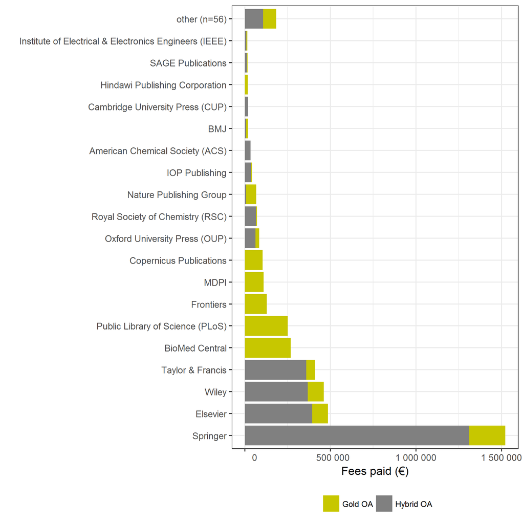

### OA journal articles

APC fees paid per publisher with indication of contribution from each university.

[figure not shown]

### Hybrid OA articles in toll access journals

APC fees paid per publisher with indication of contribution from each university.

[figure not shown]

## Fees and average APC paid per organisation

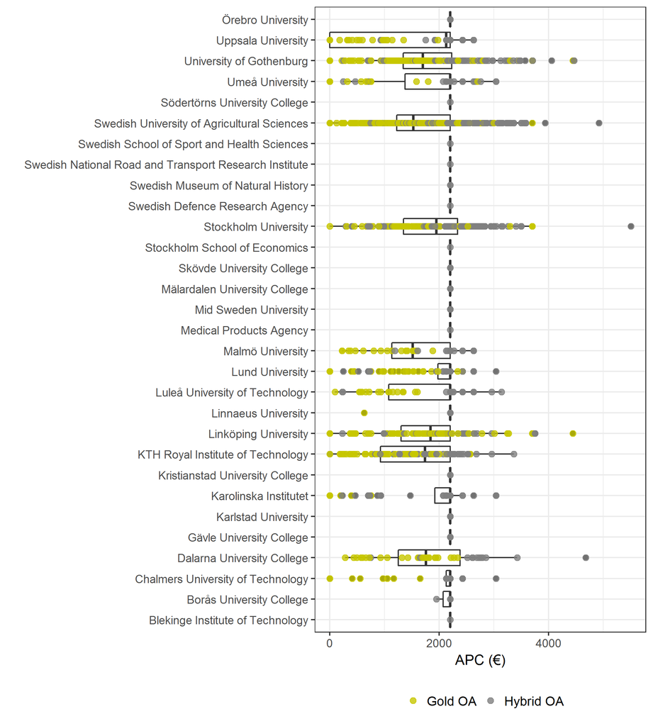

## Fees and average APC per publisher

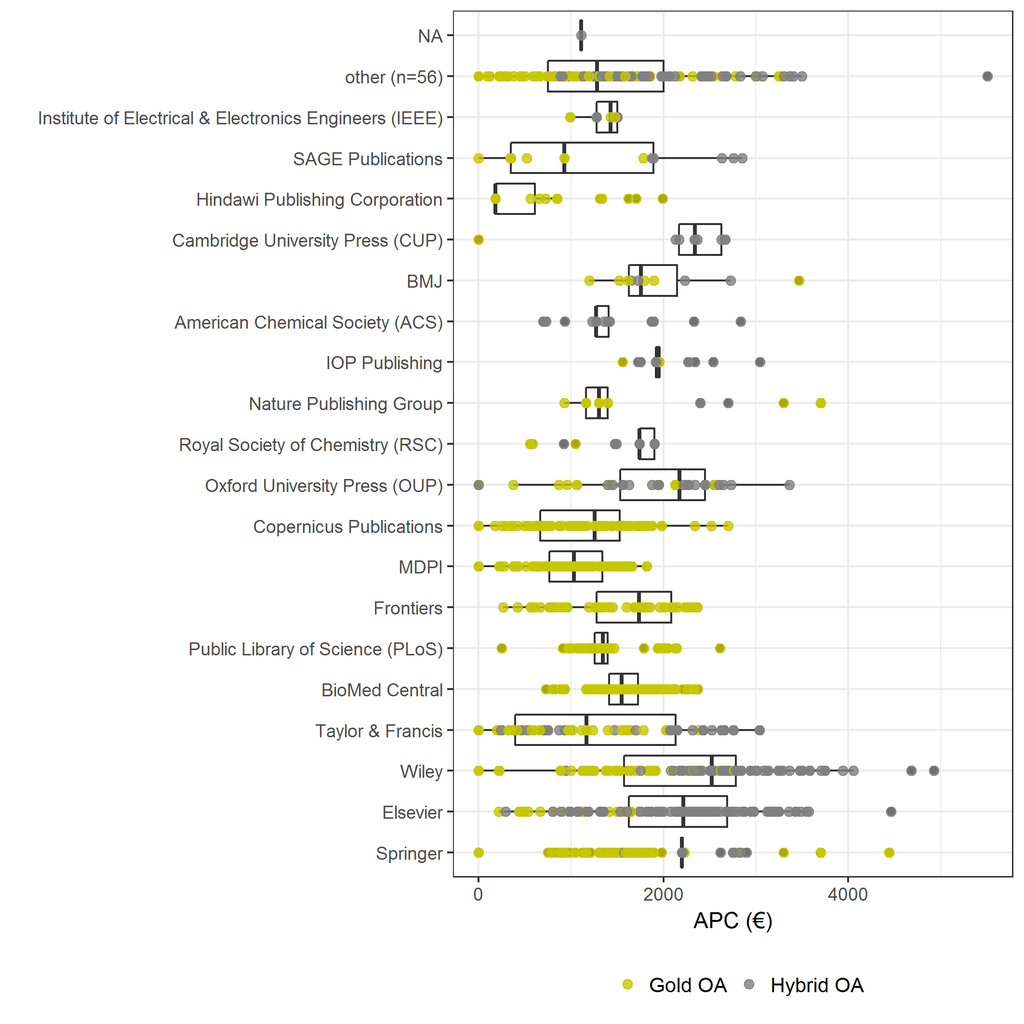

## Average and distribution of APC’s by year

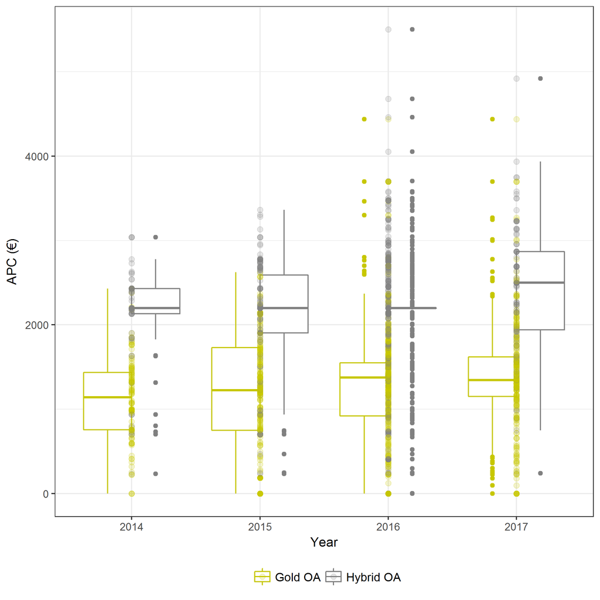

## Average APC trend by year

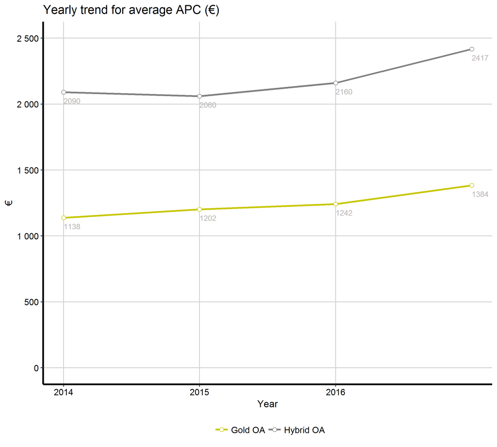

## Acknowledgement

This project follows the [Open APC Initiative](https://github.com/OpenAPC/openapc-de) to share data on paid APCs. It recognises efforts from [JISC](https://www.jisc-collections.ac.uk/Jisc-Monitor/APC-data-collection/) and [FWF](https://figshare.com/articles/Austrian_Science_Fund_FWF_Publication_Cost_Data_2014/1378610) to standardise APC reporting.

## Contact

For general comments, email Beate Eellend at the National Library of Sweden: **beate.eellend [at] kb.se**

For technical issues, email Ulf Kronman at the National Library of Sweden: **ulf.kronman [at] kb.se**